# TCA Task

Aryan Jain

17/01/2022

# Introduction

> The report focuses on exploring gender equality in the workforce for the tech sector.

**NOTE**

The term gender and sex are used interchangeably throughout the report for the sake of simplicity.

```r
library(readabs)
library(tidyverse)
```

# Methodology

## Data Source

The data for the analysis is sourced from Australian Bureau of Statistics and extracted and processed using various functions of the `readabs` library.

To read and tidy up abs source files, `read_abs` function was used. The first argument of the function takes the catalogue number of the the document which was obtained from the [ABS website](https://www.abs.gov.au/AUSSTATS/abs@.nsf/ViewContent?readform&view=ProductsbyCatalogue&Action=Expand&Num=7.2). The second argument takes the table number which can also be obtained by further exploring the website.

## Caveats

The analysis could’ve been expanded by analysing variables such as *previous experience*, *years of education*, *agegroup* and *wages* of the labour force. However, due to lack of these variables in the data filtered for the tech sector, this could not be achieved.

An forecasting model such as ARIMA or ETS could’ve been fitted to predict changes in values. However, due to COVID-19, values for the last part of the timeline were spiked and would’ve affected model predictions.

# Analysis

## Part 1

```r
lfs_emp_sex <- read_abs("6291.0.55.001", tables = 6, check_local = FALSE)
```

```
## Finding URLs for tables corresponding to ABS catalogue 6291.0.55.001
```

```
## Attempting to download files from catalogue 6291.0.55.001, Labour Force, Australia, Detailed
```

```
## Extracting data from downloaded spreadsheets
```

```
## Tidying data from imported ABS spreadsheets
```

```r
lfs_emp_sex_sep <- lfs_emp_sex %>% separate_series()
```

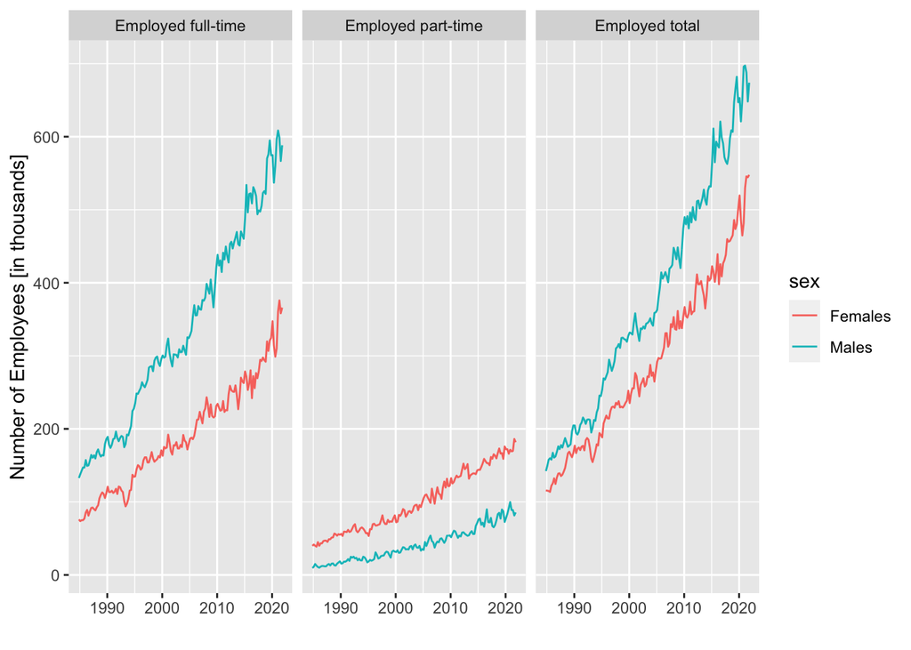

```r
lfs_emp_sex_sep_tech <- lfs_emp_sex_sep %>% filter(series_1 == "Professional, Scientific and Technical Services")
lfs_emp_final <- lfs_emp_sex_sep_tech %>%
    select(date, series_2, series_3, value) %>%
    rename("emp_type" = "series_2",
           "sex" = "series_3") %>%
    filter(sex != "Persons")

ggplot(lfs_emp_final, aes(x=date, y=value, color=sex, group=sex)) +
    geom_line() +
    facet_wrap(~emp_type) +
    labs(x="",
         y="Number of Employees [in thousands]")
```

The plot above shows the number of male and female employees employed in full-time and part-time (also total) roles over more than 3 decades. With X-axis denoting the number of years, Y-axis denoting number of employees and the faceted groups denoting employment type.

The plot clearly shows that males are more strongly represented in full-time roles while women are observed to be dominating part-time employment. This could be present due to multiple reasons,

- The first being that women choose to take up more part-time roles as they might want to take up (or burdened with) more responsibilities in their personal lives. This could be an indication of gender inequality present in the cultural foundations of the poeple.
- Or, it could also be due to the lack of equal opportunities for women in the tech sector.

To explore the reasons behind this, further analysis is conducted on underemployment in the tech sector.

*Note: The graph also shows that full-time roles are far greater in number than part-time roles which is why the findings of the third facet (Employed Total) are inline with that of Employed full-time facet.*

## Part 2

The second part of the analysis focuses on underemployment in the tech sector for both genders.

```r
lfs_unemp_sex <- read_abs("6291.0.55.001", tables = 19, check_local = FALSE)
```

```
## Finding URLs for tables corresponding to ABS catalogue 6291.0.55.001
```

```
## Attempting to download files from catalogue 6291.0.55.001, Labour Force, Australia, Detailed
```

```
## Extracting data from downloaded spreadsheets
```

```
## Tidying data from imported ABS spreadsheets
```

```r
lfs_unemp_sex_sep <- lfs_unemp_sex %>% separate_series()
```

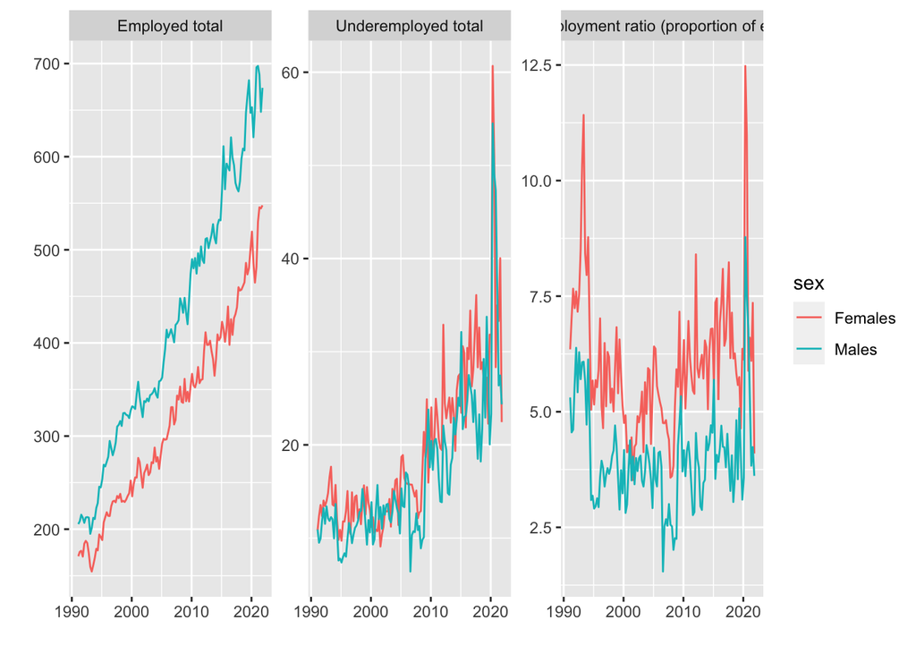

```r
lfs_unemp_sex_tech <- lfs_unemp_sex_sep %>% filter(series_1 == "Professional, Scientific and Technical Services")
lfs_unemp_sex <- lfs_unemp_sex_tech %>%
    select(date, series_2, series_3, value) %>%
    rename("emp_type" = "series_2",
           "sex" = "series_3") %>%
    filter(sex != "Persons")

lfs_unemp_sex %>%
    ggplot(aes(x=date, y=value, color=sex)) +
    geom_line() +
    facet_wrap(~emp_type, scales="free") +
    labs(x="",
         y="")
```

The plot above shows the underemployment statistics of male and female employees over more than 3 decades. With X-axis denoting the number of years, Y-axis denoting values for various statistics.

**Plot Guide** - Employed total (in thousands) - Underemployed total (in thousands) - Employment ratio (ratio of Underemployed / Employed)

# Conclusion